# 시계열분석팀 1주차 R실습

## 1. 패키지 로딩

```r
library(itsmr)
library(MASS)
library(tseries)
library(nortest)
library(forecast)
```

## 2. 데이터 불러오기

`AirPassengers` 데이터는 국제항공 여객데이터(1949 - 1960)데이터로 크게 3가지 특징이 있다.

- 추세(trend)를 갖는다; 1949년 이후 국제항공 이용자수가 지속적으로 증가
- 변동성(heteroscedasticity)이 커지고 있다; 연도가 지날수록 국제항공 이용자수의 변동성이 커지고 있다.
- 계절성(seasonality)을 갖는다; 12개월마다 반복되는 계절성이 뚜렷이 관측된다.

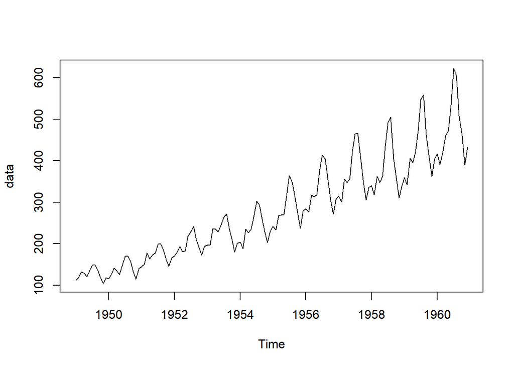

```r
data = AirPassengers
plot(data)
```

## 3. 분산안정화

분산안정화에 크게 `제곱근변환`, `로그변환`, `Box-Cox변환`이 있다.  
분산이 시간이 지나면서 커지는 경향이 있으므로, 정상성 확보를 위해 분산안정화 시켜준다.

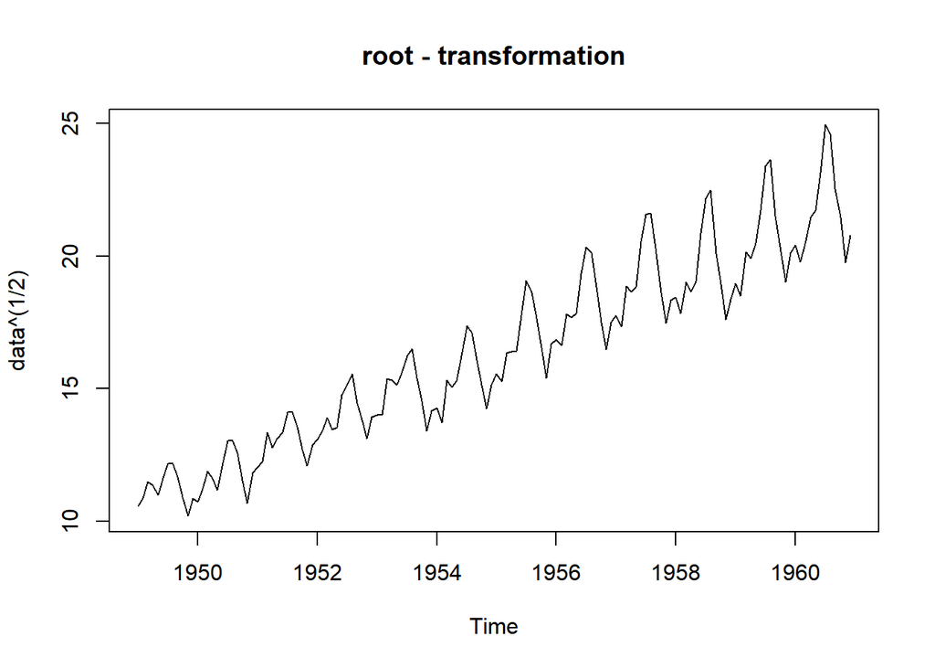

```r
plot(data^(1/2)); title('root - transformation')
```

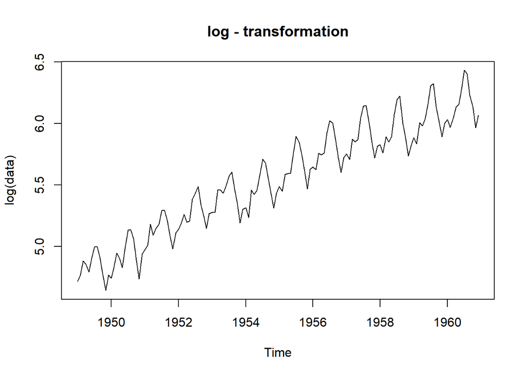

```r
plot(log(data)); title('log - transformation')
```

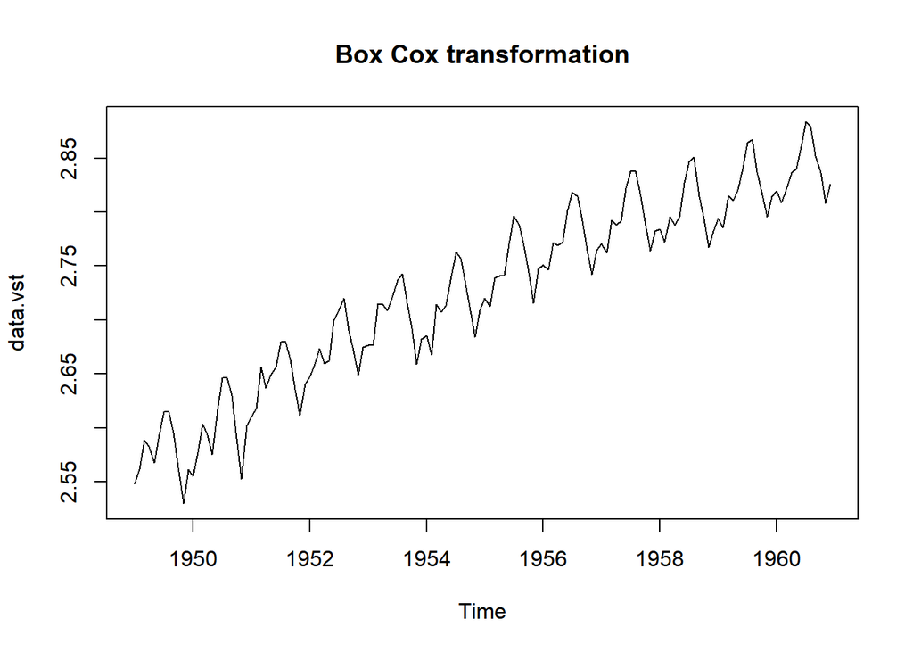

```r
lambda <- BoxCox.lambda(data)
data.vst<-BoxCox(data,lambda)
plot(data.vst);title("Box Cox transformation")
```

## 4. 회귀

분산안정화 시킨 자료에 추세와 계절성이 있어보이므로 이를 제거해 준다.  
먼저 1차식으로 추세식을 가정해 회귀를 통하여 추세를 제거한다.

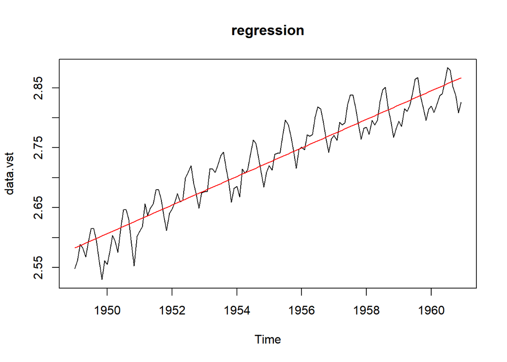

```r
n = length(data.vst)
x = seq(1,n,1)
Tt = lm(data.vst~1+x)

plot.ts(data.vst)
title('regression')
xa = as.vector(time(data.vst))
lines(xa, Tt$fitted.values,col='red')
```

추세를 제거한 식을 만들자

```r
dtrend <- data.vst - Tt$fitted.values
```

## 5.평활

평활을 통해서 추세와 계설성을 제거해볼 수 있다.  
`smooth.ma`를 사용하면, 평활을 통해 추세를 구할 수 있다.

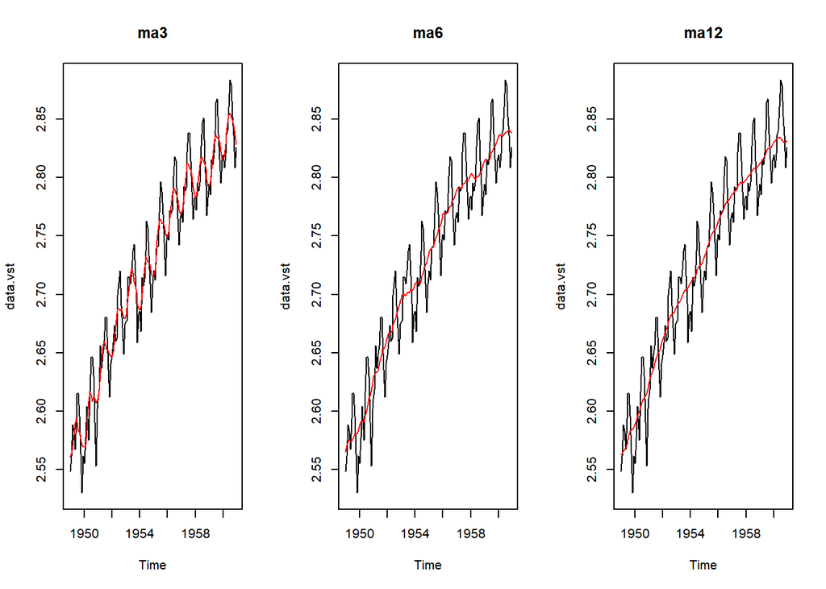

```r
ma3 = smooth.ma(data.vst, q=3)
ma6 = smooth.ma(data.vst, q=6)
ma12 = smooth.ma(data.vst, q=12)

par(mfrow = c(1,3))
plot.ts(data.vst)
title('ma3')
lines(xa,ma3,col = 'red')

plot.ts(data.vst)
title('ma6')
lines(xa,ma6,col = 'red')

plot.ts(data.vst)
title('ma12')
lines(xa,ma12,col = 'red')
```

- q가 커질 수록 더 스무스한 추세를 구할 수 있는 것을 볼 수 있다.

지수평활화를 사용해보자 `smooth.exp`를 활용하면 지수평활화를 할 수 있다.

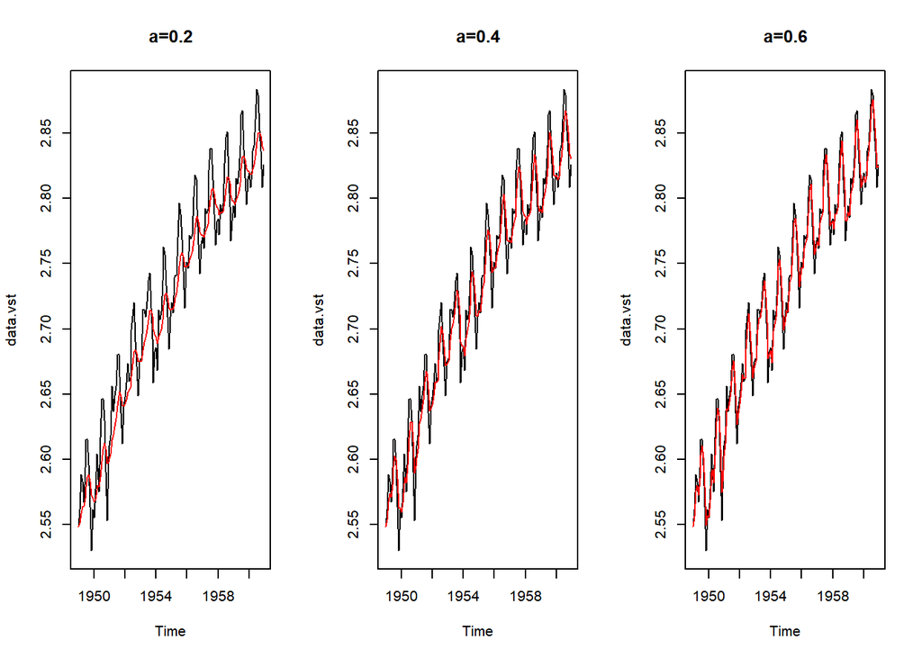

```r
ex2 = smooth.exp(data.vst,.2)
ex4 = smooth.exp(data.vst,.4)
ex6 = smooth.exp(data.vst,.6)

par(mfrow = c(1,3))

plot.ts(data.vst)
lines(xa,ex2,col = 'red');title("a=0.2")

plot.ts(data.vst)
lines(xa,ex4,col = 'red');title("a=0.4")

plot.ts(data.vst)
lines(xa,ex6,col = 'red');title("a=0.6")
```

- 평활계수a가 클수록 시계열 변화에 따른 예측값의 변화가 크게 나타나는 것을 볼 수 있다.

평활을 통해 계절성분을 분해해보자 `season`을 사용하면 계절성분을 계산해 준다.

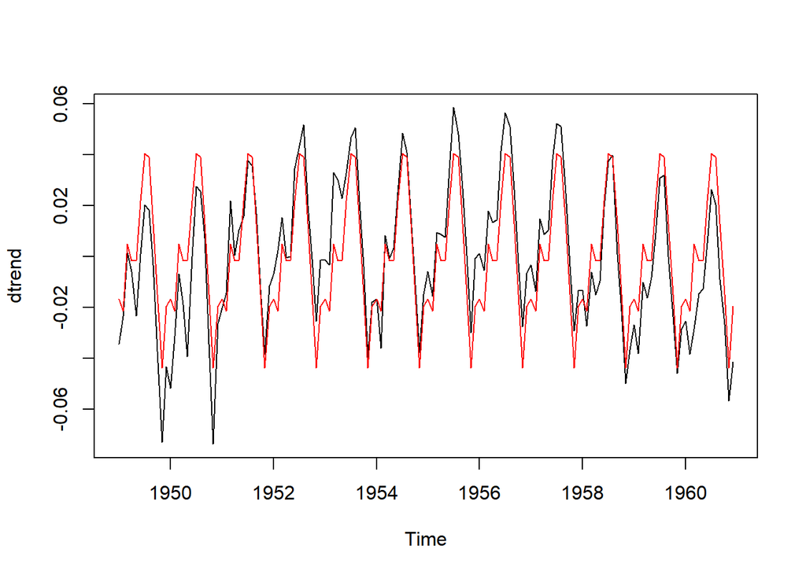

```r
season.avg = season(dtrend, d=12)
plot.ts(dtrend)
lines(xa,season.avg,col = 'red')
```

## 6. 차분

차분을 통해 추세를 제거할 수 있다. 차분함수는 `diff`이다.

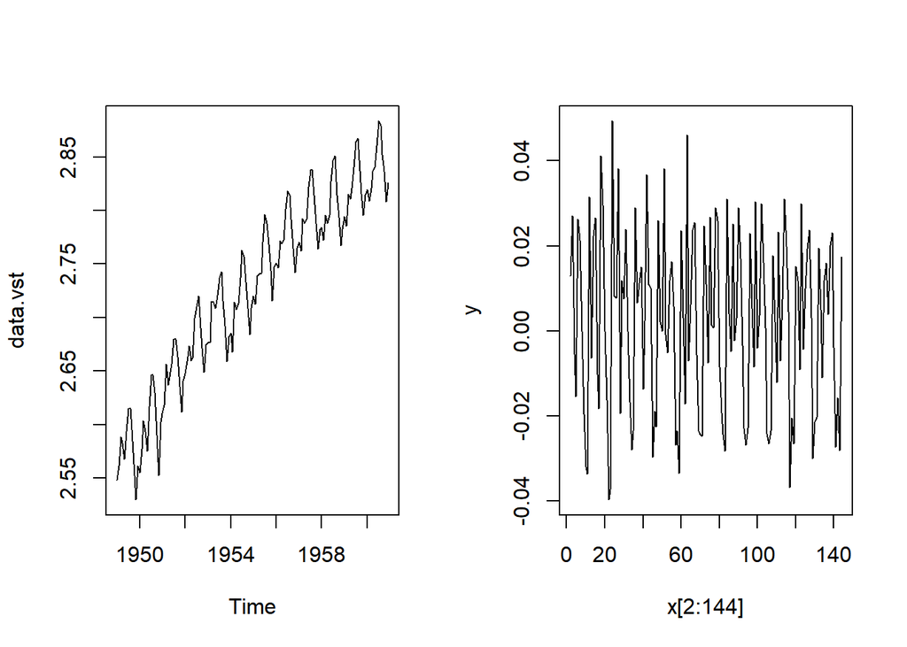

```r
y = diff(data.vst)

par(mfrow = c(1,2))
plot.ts(data.vst)
plot(x[2:144],y,type = 'l')
```

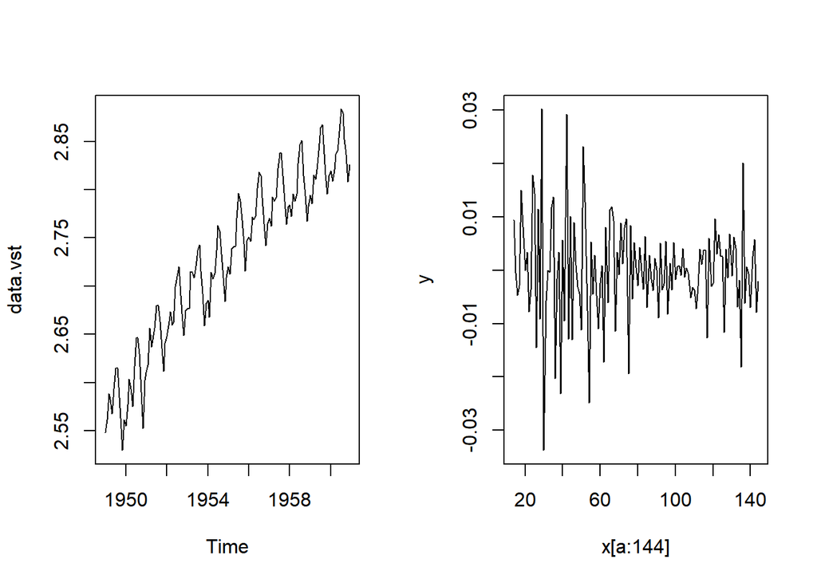

```r
diff12 = diff(data.vst, lag = 12)
y = diff(diff12)
par(mfrow = c(1,2))
plot.ts(data.vst)
a <- 145-length(y)

plot(x[a:144], y,type = 'l')
```

계절차분과 1차차분을 동시에 해보자

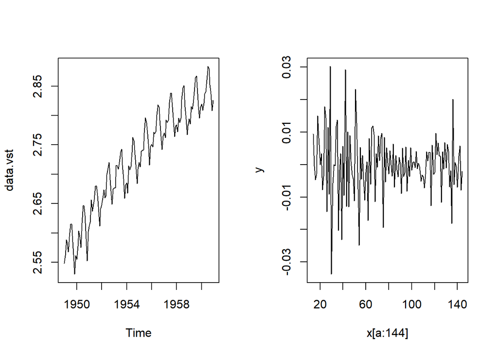

```r
diff12 = diff(data.vst, lag = 12)
y = diff(diff12)
a <- 145-length(y)

par(mfrow = c(1,2))
plot.ts(data.vst)
plot(x[a:144],y,type = 'l')
```

## 7. 잔차 검정

### ACF그래프 그리기

ACF그래프를 그려서 오차가 백색잡음인지 확인해보자

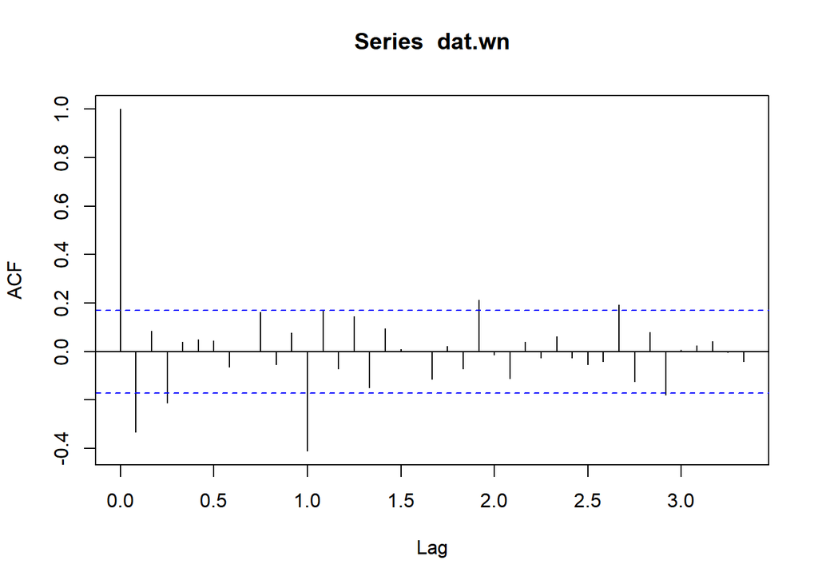

```r
dat.wn <- y
acf(dat.wn,lag.max = 40)
```

### 자기상관 검정

귀무가설을 기각하므로, 자기상관이 있다고 할 수 있다.

```r
Box.test(dat.wn,lag=10,type="Ljung-Box")
```

```
##
##  Box-Ljung test
##
## data:  dat.wn
## X-squared = 27.347, df = 10, p-value = 0.002294
```

### 정규성검정

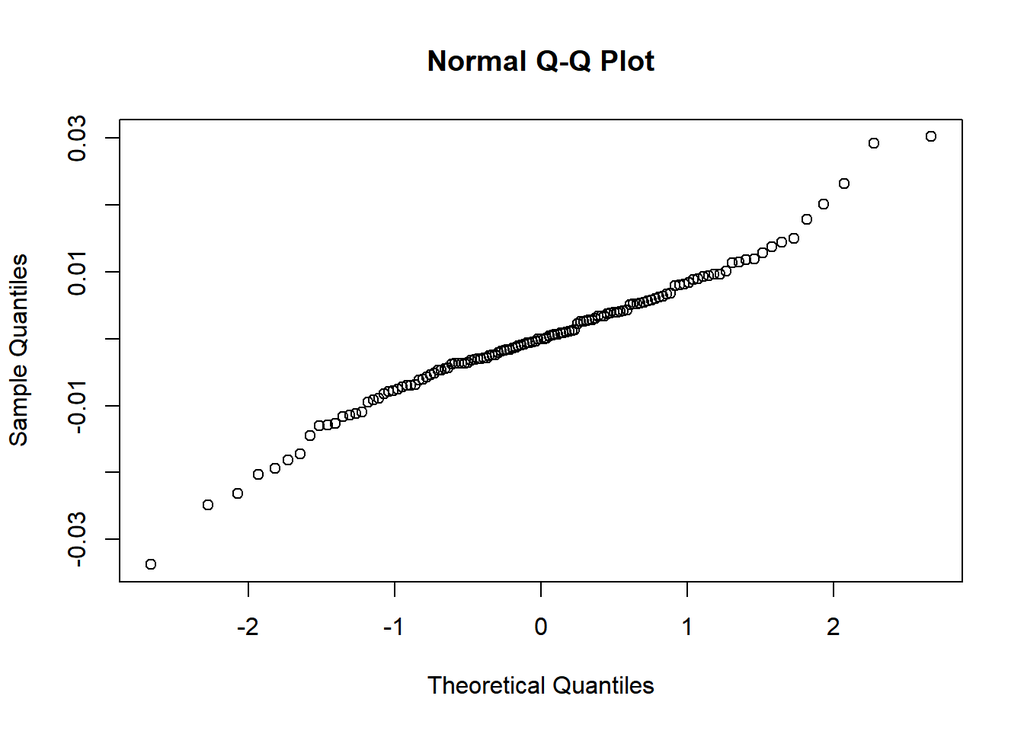

```r
qqnorm(dat.wn)
```

```r
jarque.bera.test(dat.wn)
```

```
##
##  Jarque Bera Test
##
## data:  dat.wn
## X-squared = 17.246, df = 2, p-value = 0.0001799
```

### 정상성 검정

#### adf테스트

- 귀무가설 : 이데이터는 비정상적이다.
- 대립가설 : 이데이터는 정상적이다.

```r
adf.test(dat.wn)
```

```
##
##  Augmented Dickey-Fuller Test
##
## data:  dat.wn
## Dickey-Fuller = -5.2679, Lag order = 5, p-value = 0.01
## alternative hypothesis: stationary
```

#### kpss 테스트

- 귀무가설: 데이터가 정상적이다.
- 대립가설 : 데이터가 비정상적이다.

```r
kpss.test(dat.wn)
```

```
##
##  KPSS Test for Level Stationarity
##
## data:  dat.wn
## KPSS Level = 0.086789, Truncation lag parameter = 4, p-value = 0.1
```

## 8.Classical Deomposition

`decompose`라는 함수를 사용하면, 추세, 계절성, 오차를 한번에 분리할 수 있다.

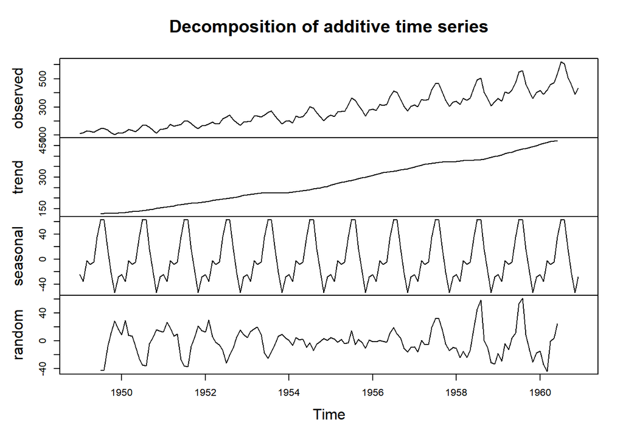

```r
plot(decompose(data))
```

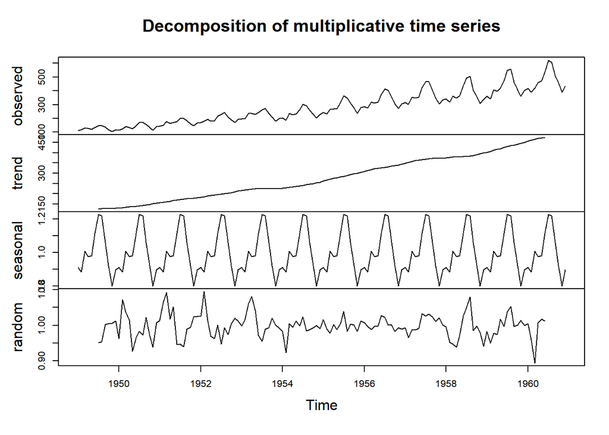

```r
plot(decompose(data, type="multiplicative"))
```

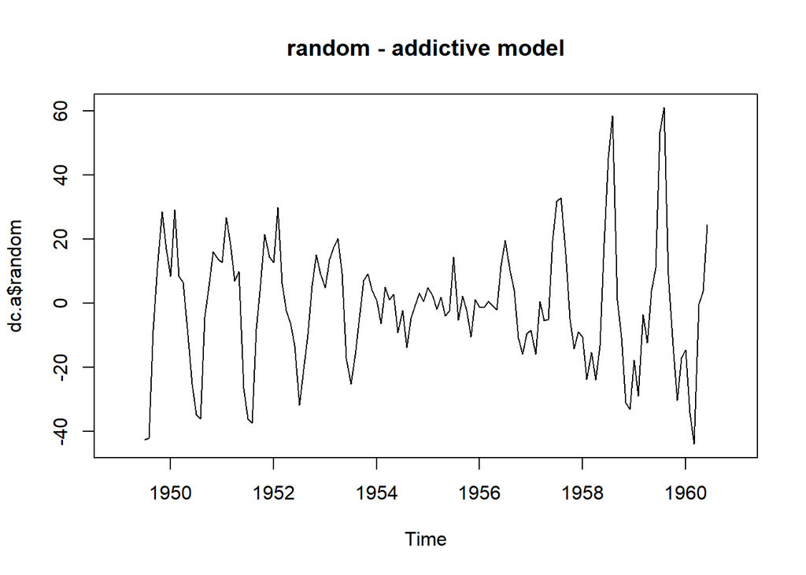

```r
dc.m <- decompose(data, type="multiplicative")
dc.a <- decompose(data)
plot(dc.a$random);title("random - addictive model")
```

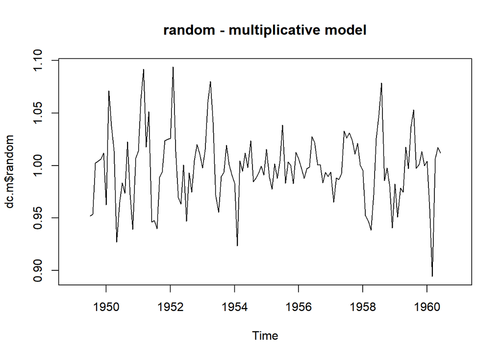

```r
plot(dc.m$random);title("random - multiplicative model")
```

## acf그래프로 확인

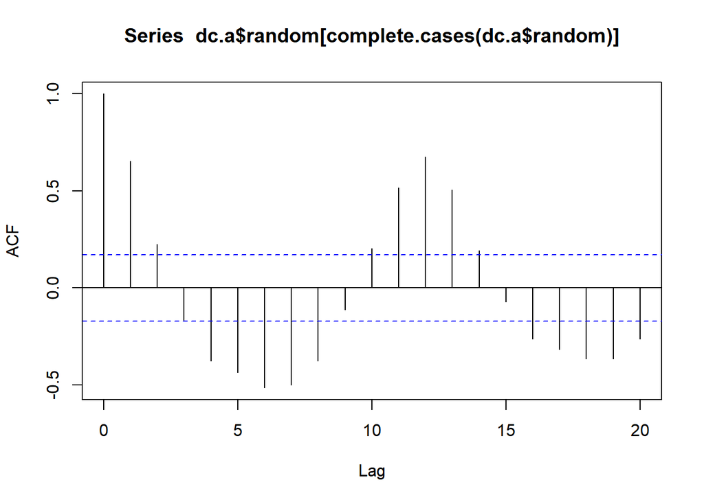

```r
acf(dc.a$random[complete.cases(dc.a$random)],lag.max = 20)
```

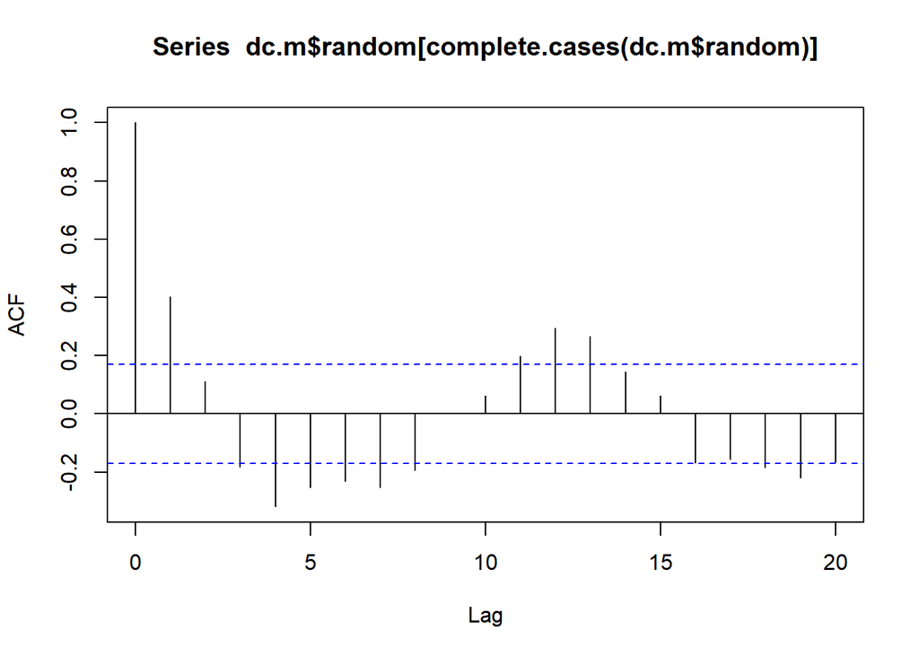

```r
acf(dc.m$random[complete.cases(dc.m$random)],lag.max = 20)
```

- 백색잡음이 아니기에 추가적인 모델링이 필요하다!!
- 2주차에 배울거에용~!